# Projet apprentissage statistiques - Etude SpeedDating

2021

## Description du problème et des données

## Description du problème

- L’amour : Comment mettre en relation les personnes qui ont le plus le chance de s’aimer ?
- Données issues de SpeedDating

[figure not shown]

## Table des matières

- Présentation du jeu de données
- Preprocessing & Nettoyage
- Visualisation et Statistiques Descriptives
- Les modèles
- Le modèle retenu et conclusion

## Présentation de la base de données

- Base de données recupérée sur [kaggle](https://www.kaggle.com/annavictoria/speed-dating-experiment)
- Données brutes :
  - 8379 lignes et 195 variables
  - variable à expliquer : match
  - Variables explicatives : 73 variables de type identification –> nettoyage

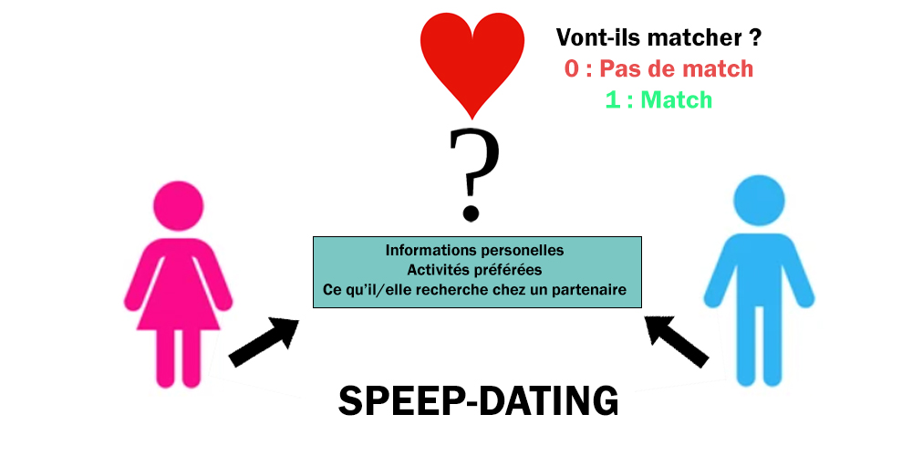

## Présentation de la base de données

- Variable à expliquer *match* : 84% de 0 (pas de match entre le couple) et 16% de 1 (match) —> données déséquilibrées

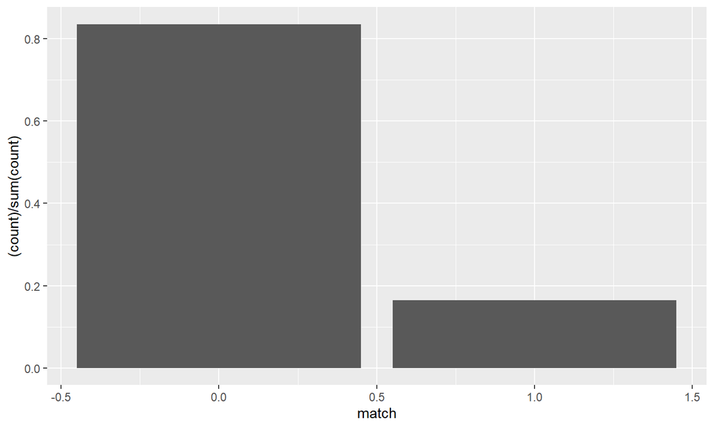

## Preprocessing

# Nettoyage du jeu de données

- Gerer les problemes de codage
- Harmoniser le système de points
- Gestion des valeurs manquantes
- Suppression de variables inutilisables pour répondre à la problématique
- Joindre les informations

# Création de nouvelles variables

- Aggréger certaines modalités des variables qualitatives
- Variable comptage
- Variables représentant la distances entre les partenaires

## Présentation et visualisation des donnees

## Visualisation & Statistiques descriptives

- Corrélation : Les activités pratiquées par les femmes

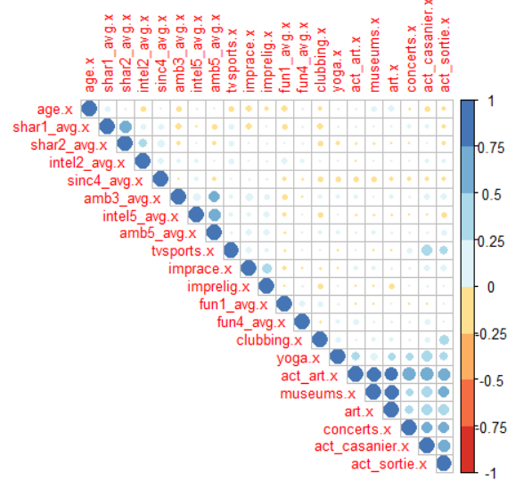

## Visualisation & Statistiques descriptives

- Corrélation : Les activités pratiquées par les hommes

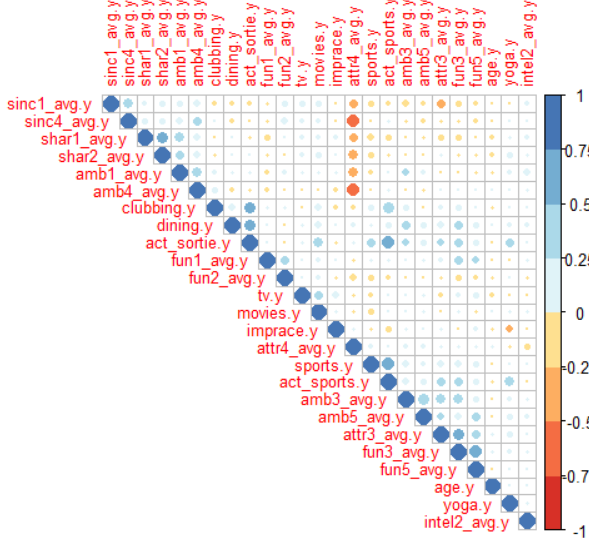

## Visualisation & Statistiques descriptives

- Corrélation : Ce que les personnes du même sexe recherche

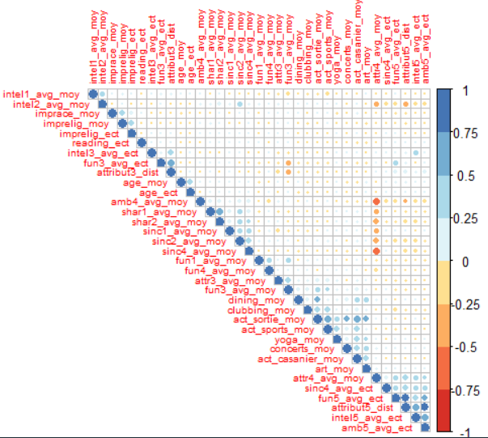

## Visualisation & Statistiques descriptives

- Corrélation : Rapport de corrélation entre les variables quantitatives et la variable réponse

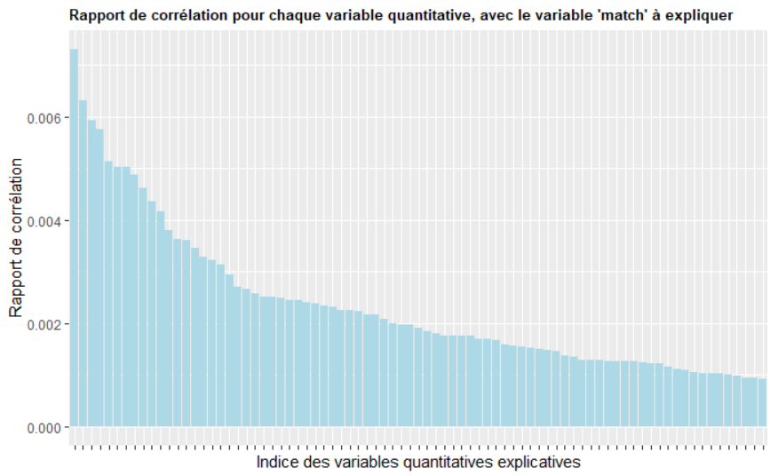

## Visualisation & Statistiques descriptives

- Significativité : Test de Student pour chaque variable quantitative et la variable réponse

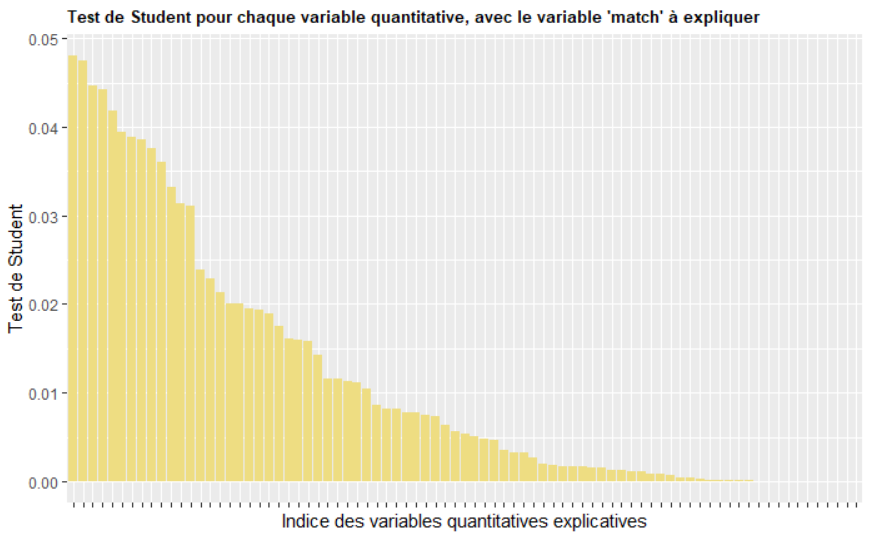

## Visualisation & Statistiques descriptives

- Corrélation : V de Cramer pour chaque variable qualitative avec la variable réponse

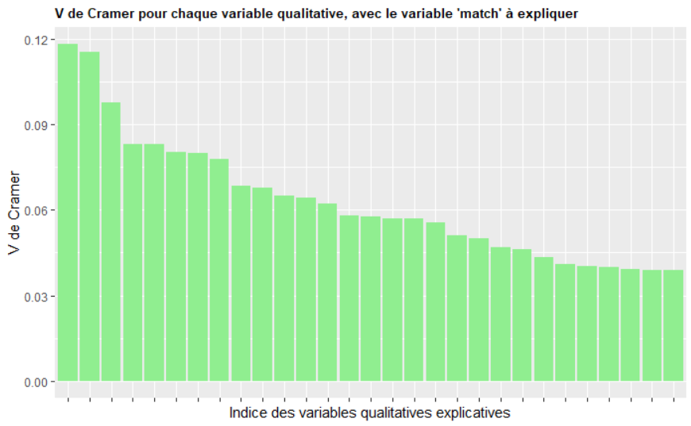

## Critères de performance

## Critères de performance

- Données déséquilibrées : 84% d’exactitude en prédisant que des 0
- Mettre l’accent sur le taux de match détecté :
  - Precision, Sensibilité et F1-Score
  - Ne pas négliger la performance globale (l’exactitude)

## Critères de performance

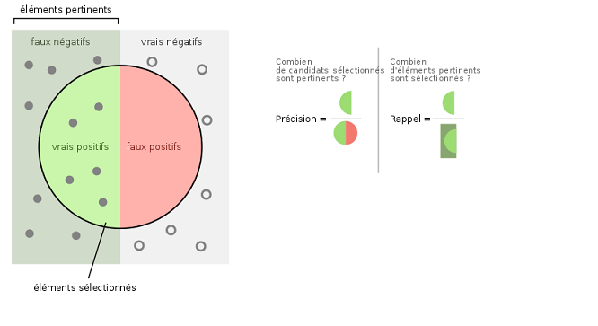

## Régression Logistique (Modèle 1/5)

## Régression Logistique

- Modèle “naturel” pour une classification binaire
- 100+ variables –> fléau de la dimension
- Reduction du nombre de variables avec **caret**

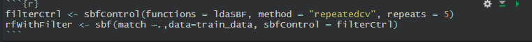

- Passage de 100+ variables à 44 variables

## Premier résultat

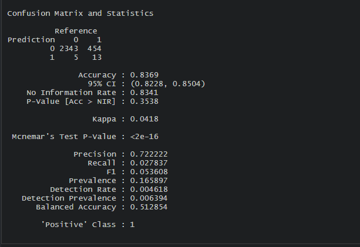

- Mauvaise performance au vu de nos critères
- Hypothèse : cela est du au déséquilibre des données

## Suréchantillonage (Oversampling)

- Randomly Over Sampling Examples (ROSE) : equilibrage des données
- “Nouvelle” base d’apprentissage
- Ajustement d’un nouveau modèle et meilleurs résultats

## Résultats

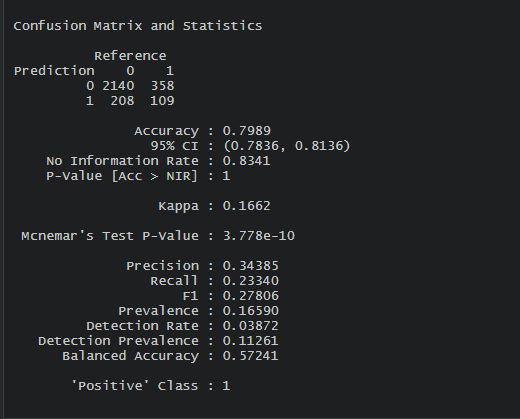

–

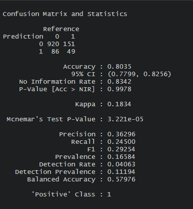

- Regression Logistique normale inadaptée

## Régression de Lasso : 4 modèles (Modèle 2/5)

## Régression de Lasso : Sans sampling

- Optimisation de l’hyper-paramètre Lambda

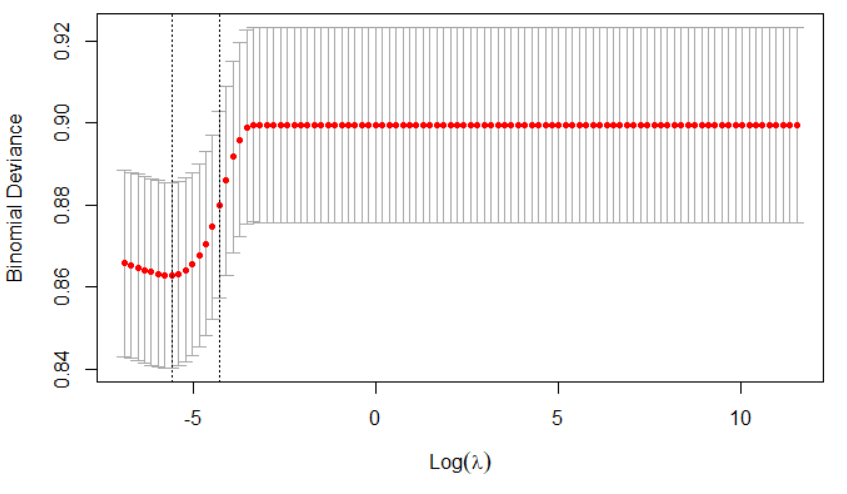

## Régression de Lasso : Sans sampling

- Résultats obtenus

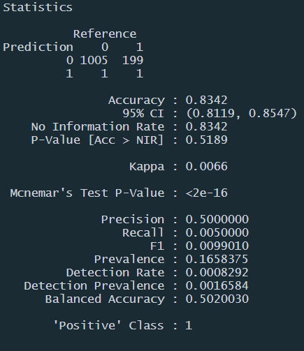

## Régression de Lasso : Avec Rose

- Optimisation de l’hyper-paramètre Lambda

[figure not shown]

## Régression de Lasso : Avec Rose

- Résultats obtenus

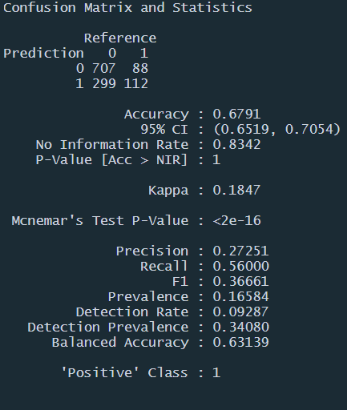

## Régression de Lasso : Avec Over-Sampling

- Optimisation de l’hyper-paramètre Lambda

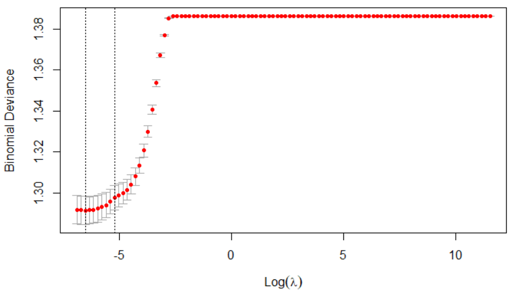

## Régression de Lasso : Avec Over-Sampling

- Résultats obtenus

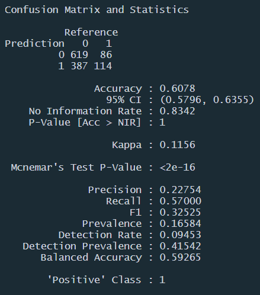

## Régression de Lasso : Avec Under-Sampling

- Optimisation de l’hyper-paramètre Lambda

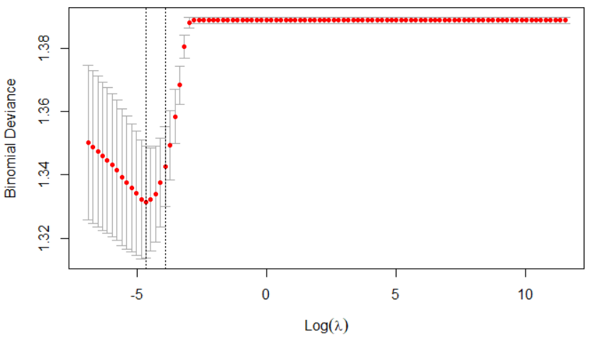

## Régression de Lasso : Avec Under-Sampling

- Résultats obtenus

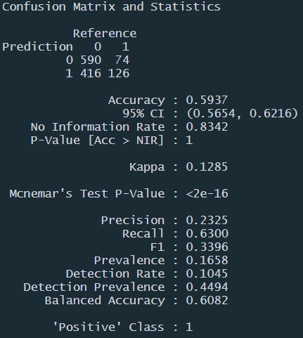

## Régression avec Lasso : Résumé des scores

- Tableau des scores pour différents sampling

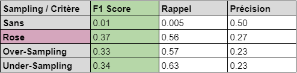

## SVM (Modèle 3/5)

## Premier modèle

- Modèle SVM linéaire sur la base initiale

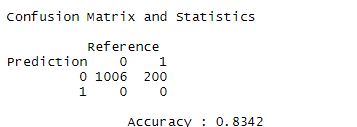

- Mauvais modèle qui classifie tout comme des couples non match parce que cela donne un taux 83.4% des couples correctement prédites

—> Due au déséquilibre dans la base de données

- Solution : Surechantillonage de ROSE

## Les modèles obtenus avec la nouvelle base de données d’apprentissage avec ROSE

- Modèles testés : SVM linéaire, SVM radial, SVM polynomial.
- Pour chaque modèle, on retire la précision, la sensibilité et le F1 score pour les comparer à la fin.

## SVM linéaire

- Séparation des données par un seuil linéaire
- **Pénalisation** de la mauvaise classification
- **Cout** de pénalisation à calibrer

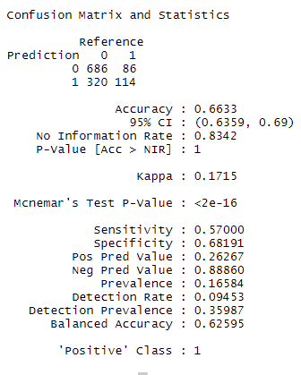

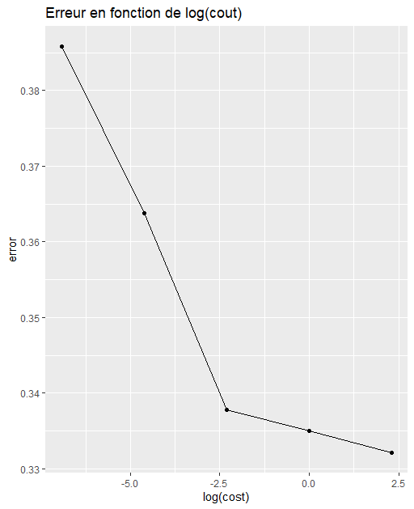

## SVM radial

- Séparation des données par un seuil radial
- **Cout** de pénalisation à calibrer

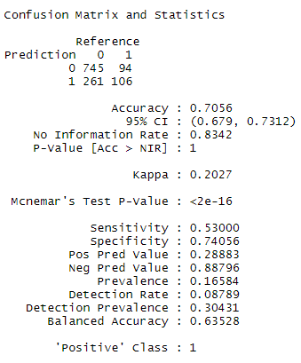

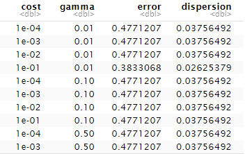

**Meilleur modèle** : Cout = 0.1, Gamma = 0.01

## SVM polynomial

- Séparation des données par un seuil polynomial
- **Cout** de pénalisation à calibrer
- **Degrès** du polynome à calibrer

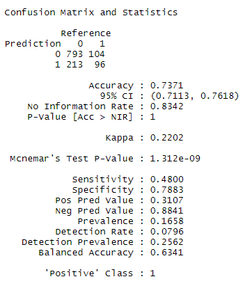

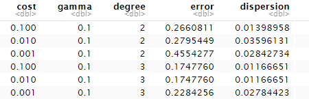

**Meilleur modèle** : Cout = 0.1, Degree = 3

## Comparaison des 3 modèles

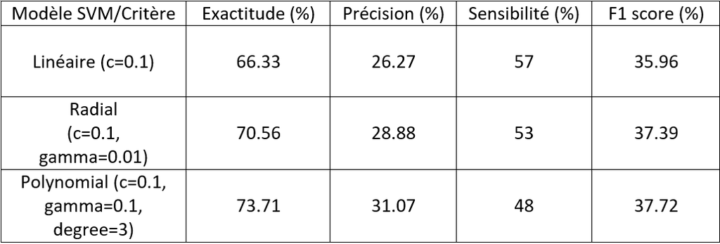

**Meilleur modèle** : SVM polynomial de degré 3 avec le cout égal à 0.1